# Final Report_Kickstarter

#### 6.Segmentation

**a.Apriori Segmentation**  
From our analysis above, we found that there are significant segments based on month and category. The kickstarter of manager should customize its campaign strategy for different categories in different months.  
From our logistic regression above, we found that goal, backers and main category affect the state of a project.From our linear regression above, we realized that ‘backers’ is a determinant of the pledge amount of one project and the effect of bakcers on pledge amount is affected by categories. However, the effect of goal on pledge amount is relatively small.From our aggregation regression above, we realized that except for considering months and categories, kickstarter should also change its campaign plan for projects from different countries.

**b.Post-hoc Segmentation**  
We used the k-means method to do the Post-hoc Segmentation. We inputed bakcers, goal, and isSuccessful and got a segmentaion of four groups.

```r
seg.summ <- function(data, groups) {
  aggregate(data, list(groups), function(x) mean(as.numeric(x)))
}
seg.df.num = select(df,backers,goal,isSuccessful)
scaled_data = scale(seg.df.num)
set.seed(12345678)
k.max <- 15
wss <- sapply(1:k.max,
              function(k){kmeans(scaled_data, k, nstart=50,iter.max = 20 )$tot.withinss})
wss
```

```
##  [1] 995022.00 657913.01 391265.77 228034.61 158386.85 122450.32  92304.23
##  [8]  79452.04  68735.63  61747.36  57709.00  41421.97  30705.56  26952.17
## [15]  23842.00
```

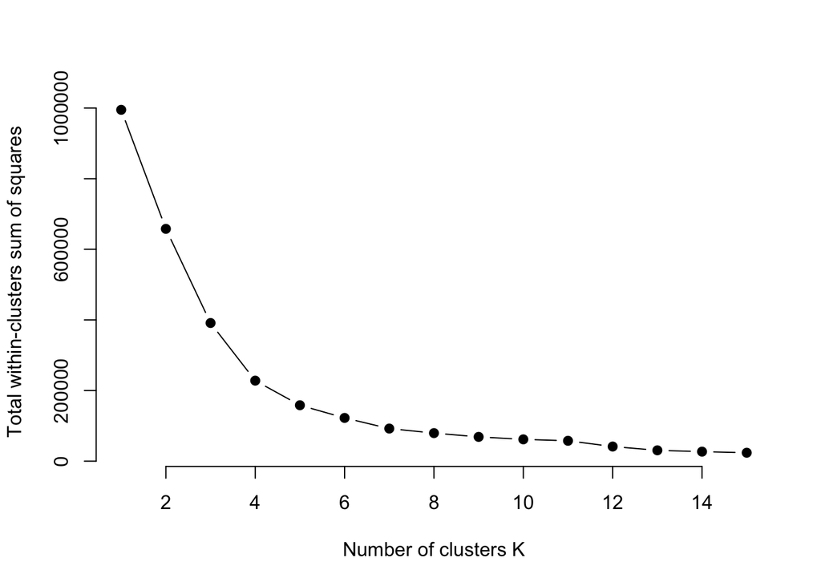

```r
plot(1:k.max, wss,
     type="b", pch = 19, frame = FALSE,
     xlab="Number of clusters K",
     ylab="Total within-clusters sum of squares")
```

```r
set.seed(12345678)
seg.k4 <- kmeans(scaled_data, centers=4, nstart = 50, iter.max = 20 )
seg<-data.frame(seg.summ(seg.df.num, seg.k4$cluster)) %>% pandoc.table(style='simple')
```

```
##
##
##  Group.1   backers     goal     isSuccessful
## --------- --------- ---------- --------------
##     1       59735     524843         1
##     2       244.8      9367          1
##     3       16.43     43107          0
##     4       4.833    82704866        0
```

**Analysis**  
Based on the characteristic of the four groups, we define group 1 as ‘the second highest goal with the highest number of backers’, group 2 as ‘the lowest goal with the second highest number of backers’, group 3 as ‘the third highest goal with the third highest number of backers’ and group 4 as ‘the highest goal with the lowest backers’. Group 1 and Group 2 are successful projects.

Kickstarter should set a system to evaluate the optimal goal of a project and avoid a project setting unreachable pledge goal. We can see that projects with a small number of backers cannot make it. Kickstarter should help promote for projects to attract more backers. For popular projects with a great number of supporters, Kickstarter can help the project set a relatively high goal of pledge amount.

**add the segmentention_group variable into previous regression**

```r
#compare with the old regression without segmentation_group
lm_inter = lm(pledged~goal+backers+factor(main_category)+factor(main_category)*backers,data = df)
model.sel = data.frame(Adj.RSq = c(summary(lm_inter)$adj.r.squared,
                                   summary(lm_segmentation)$adj.r.squared),
                       AIC = c(AIC(lm_inter),
                               AIC(lm_segmentation))) %>% round(4)
Regression=c('Before_segementation','After_segmentation')
model.sel=cbind(Regression,model.sel);pandoc.table(model.sel,style='simple')
```

```
##
##
##       Regression        Adj.RSq     AIC
## ---------------------- --------- ---------
##  Before_segementation   0.6065    8247028
##   After_segmentation    0.6091    8244844
```

We added the segmentation_group variable into the regression and found that Adj.RSq is increased and AIC is decreased. Thus, the result of the Post-jac segmentation is useful.

#### 7.Prediction

**a. Predicting Goal: pledged amount**

Our predicting goal is pledged amount of a project. With prediction, we can compare pledged amount with the project’s funding goal to investigate the gap to success. Also, Kickstarter charges the successful project teams by a certain fee rate of pledged amount. Thus, predicting pledged amount will help us predict the revenue.

**b. Data Spliting**

```r
setwd("~/Desktop/BUS256/Project")
df2 <- read_csv("~/Desktop/BUS256/Project/kickstarter-projects/ks-projects-201801.csv")
#We used live projects as test data for prediction.
test.data = df2 %>%filter(state == 'live')%>%
  mutate(category = factor(category),main_category=factor(main_category),state=factor(state),country=factor(country))
set.seed(12345678)
validation.index = sample(seq(1,nrow(df)), floor(0.10*nrow(df)))
validation.data = df[validation.index, ]
training.data = df[-validation.index, ]
prediction.error = function(lm_model, test.data){
  predicted.pledged = predict(lm_model, test.data)
  error = sqrt(mean((predicted.pledged-test.data$pledged)^2))
}
```

**c. 15 regression models**

```r
lm_1 = lm(pledged~backers, data = training.data)
lm_2 = lm(pledged~backers+goal, data = training.data)
lm_3 = lm(pledged~backers+goal+backers*goal, data = training.data)
lm_4 = lm(pledged~backers+goal+factor(main_category), data = training.data)
lm_5 = lm(pledged~backers+goal+factor(main_category)*goal, data = training.data)
lm_6 = lm(pledged~backers+goal+factor(main_category)*backers, data = training.data)
lm_7 = lm(pledged~backers+goal+factor(main_category)*factor(EndMonth), data = training.data)
lm_8 = lm(pledged~backers+goal+factor(main_category)*backers+factor(EndMonth),data = training.data)
lm_9 = lm(pledged~backers+goal+factor(main_category)*backers+factor(EndMonth)*backers, data = training.data)
lm_10 = lm(pledged~backers+goal+factor(main_category)*backers+factor(EndMonth)*factor(main_category), data = training.data)
lm_11 = lm(pledged~backers+goal+factor(main_category)*backers+factor(EndMonth)*backers+country, data = training.data)
lm_12 = lm(pledged~backers+goal+factor(main_category)*backers+factor(EndMonth)*backers+country*factor(main_category), data = training.data)
lm_13 = lm(pledged~backers+goal+factor(main_category)*backers+factor(EndMonth)*backers+country*factor(EndMonth), data = training.data)
lm_14 = lm(pledged~backers+goal+factor(main_category)*backers+factor(EndMonth)*backers+country*backers, data = training.data)
lm_15 = lm(pledged~backers+goal+factor(main_category)*backers+factor(EndMonth)*backers+country*backers+factor(segmentation_group), data = training.data)
```

Next, we calculated the predicted error.

```r
error_model1 = prediction.error(lm_1, validation.data)
error_model2 = prediction.error(lm_2, validation.data)
error_model3 = prediction.error(lm_3, validation.data)
error_model4 = prediction.error(lm_4, validation.data)
error_model5 = prediction.error(lm_5, validation.data)
error_model6 = prediction.error(lm_6, validation.data)
error_model7 = prediction.error(lm_7, validation.data)
error_model8 = prediction.error(lm_8, validation.data)
error_model9 = prediction.error(lm_9, validation.data)
error_model10 = prediction.error(lm_10, validation.data)
error_model11 = prediction.error(lm_11, validation.data)
error_model12 = prediction.error(lm_12, validation.data)
error_model13 = prediction.error(lm_13, validation.data)
error_model14 = prediction.error(lm_14, validation.data)
error_model15 = prediction.error(lm_15, validation.data)

data.frame(Names = c("1","2", "3",
                     "4", "5", "backers+goal+factor(main_category)*backers","7"," 8","9","10","11","12","13","14","15"),
           Error = c(error_model1,error_model2, error_model3, error_model4, error_model5,     error_model6,error_model7,error_model8, error_model9, error_model10, error_model11, error_model12,error_model13, error_model14, error_model15 ))
```

```
##                                         Names    Error
## 1                                           1 75370.99
## 2                                           2 75370.21
## 3                                           3 74508.42
## 4                                           4 75290.90
## 5                                           5 75285.08
## 6  backers+goal+factor(main_category)*backers 71945.15
## 7                                           7 75292.24
## 8                                           8 71945.86
## 9                                           9 73033.21
## 10                                         10 71945.74
## 11                                         11 73038.05
## 12                                         12 73040.19
## 13                                         13 73042.93
## 14                                         14 72395.20
## 15                                         15 72830.76
```

**d. the best model**

Our best model is the one with the lowest prediction error:

pledged= backers+ goal+ factor(main_category) x backers

**e. predict the pledge amount**

```r
#clean the test data
max(test.data$launched)
```

```
## [1] "2018-01-02 15:02:31 UTC"
```

```r
test.data<-test.data %>% filter(state=='live'& deadline>='2018-01-02')
test.data$launched<-substr(test.data$launched, 1, 10)
test.data$launched = as.Date(test.data$launched, "%Y-%m-%d")
test.data<-test.data %>% mutate(currentdate='2018-01-02')
test.data$currentdate = as.Date(test.data$currentdate , "%Y-%m-%d")
test.data<-test.data %>% mutate(before=currentdate-launched,period=deadline-launched)
test.data$before<-as.numeric(test.data$before)
test.data$period<-as.numeric(test.data$period)
#Caculate the final number of backers
test.data<-test.data %>% mutate(backers_rate=backers/before,
                                predicted_backers=backers_rate*period)
test.data<-test.data %>% mutate(backers_unadjusted=backers,backers=predicted_backers)
```

For live prjects, they hadn’t reached their deadlines by 2018-01-02 when we collected data. Thus, the number of backers changes over time. We assumed that the growth rate of backers is constant and we treated the growth rate of backers before 2018-01-02 as the growth rate during the whole process to caculate the final number of backers.

```r
#predict
predicted.y = predict(lm_6 , test.data, se.fit = TRUE)
```

**f. Calculating the 95% confidence interval for the predicted pledge amount.**

```r
test.data$predicted.y = predicted.y$fit
test.data$se.fit = predicted.y$se.fit
test.data$upper.limit = test.data$predicted.y + qnorm(0.975)*test.data$se.fit
test.data$lower.limit = test.data$predicted.y - qnorm(0.975)*test.data$se.fit
```

Also, we caculated the condifence interval for each live project. The pledge amount of each project has 95% probablity to lie in its confidence interval.

```r
test.data$predict.state=ifelse(test.data$predicted.y>test.data$goal,'successful','failed')
sum(is.na(test.data$predicted.y))#number of observations where predicted y is NA
```

```
## [1] 39
```

```r
df_na<-test.data%>%filter(is.na(test.data$predicted.y))
test.data<-test.data %>% filter(!is.na(test.data$predicted.y))
sum(test.data$predicted.y<0)#number of observations where predicted y<0
```

```
## [1] 184
```

```r
df_negative<-test.data %>% filter(test.data$predicted.y<0)
test.data<-test.data %>% filter(test.data$predicted.y>0)
data.frame(Predicted_y=c("N.A.","Negative"), Number_observation=c("39","184"))
```

```
##   Predicted_y Number_observation
## 1        N.A.                 39
## 2    Negative                184
```

**Analysis**

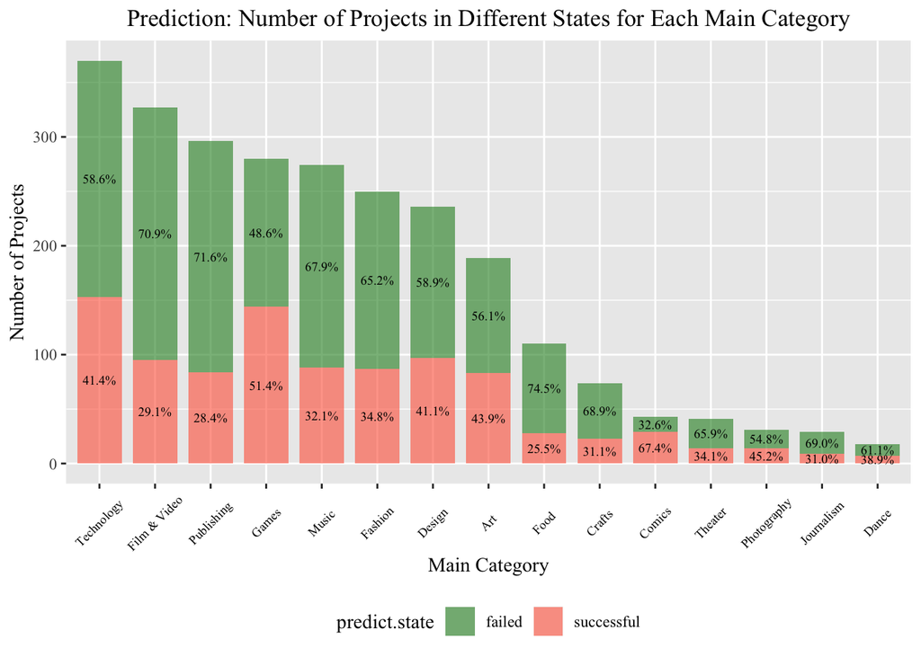

```r
df_test = test.data %>% group_by(main_category,predict.state)  %>% summarise(quantity =  n())
df_test = df_test %>% mutate(proportion = quantity/sum(quantity))
df_test %>%
  #ggplot(aes(x=fct_rev(reorder(main_category,quantity)),y = quantity)) +
  ggplot(aes(x=fct_rev(reorder(main_category,quantity)),y = quantity)) +
  geom_bar(aes(fill = predict.state), stat = 'identity', position = 'stack', alpha = 0.6, width = .8) +
  scale_fill_manual(values = c("forestgreen", 'tomato', "black")) +
  geom_text(aes(label = percent(proportion),group = predict.state), position = position_stack(vjust = 0.5), family = "Times New Roman", size = 2.5) +
  theme(axis.text.x = element_text(size = 7, color = "black", face = "plain", vjust = 0.5, hjust = 0.5, angle = 45),plot.title = element_text(hjust = 0.5),text=element_text(family="Times New Roman"), legend.position = "bottom") +
  ggtitle("Prediction: Number of Projects in Different States for Each Main Category") +
  xlab("Main Category") +
  ylab("Number of Projects")
```

**Prediction Analysis**

Based on our prediction, we found categories with the five highest successful rates are Comics, Games, Photography, Art and Technology. However, Comics and Photography have relative small numbers of projects.

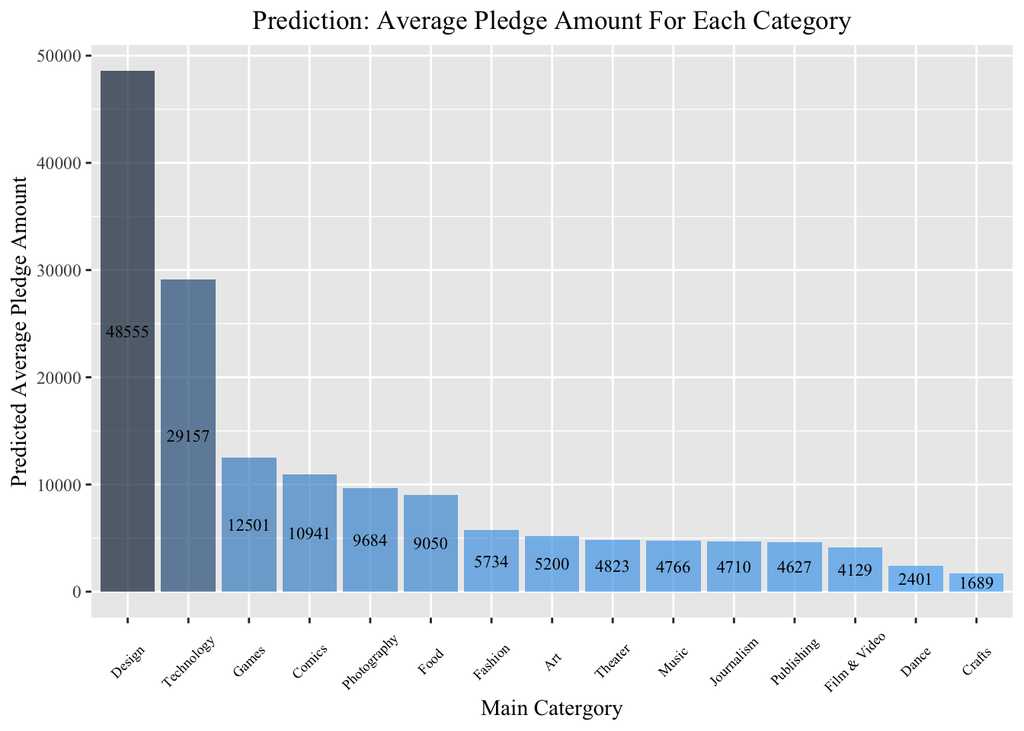

```r
df_test1 = test.data %>%
  group_by(main_category)%>%
  summarise(avg_pledge = mean(predicted.y))%>%
  arrange(desc(avg_pledge))

df_test1 %>%
  ggplot(aes(x=fct_rev(reorder(main_category,avg_pledge)),y=avg_pledge,fill=avg_pledge))+
  geom_bar(stat = 'identity',alpha = 0.7)+
  theme(legend.position="none") +
  ggtitle("Prediction: Average Pledge Amount For Each Category") +
  xlab("Main Catergory") +
  ylab("Predicted Average Pledge Amount") +
  theme(axis.text.x = element_text(size = 7, color = "black", face = "plain", vjust = 0.5, hjust = 0.5, angle = 45),plot.title = element_text(hjust = 0.5),text=element_text(family="Times New Roman"))+
  scale_fill_continuous(trans = 'reverse')+
  geom_text(aes(label = round(avg_pledge,0)), position = position_stack(vjust = 0.5), family = "Times New Roman", size = 3)
```

According to our visualization, we predicted the average pledge amount of each category. Design and Technology have significantly large amounts of predicted average pledge amount.

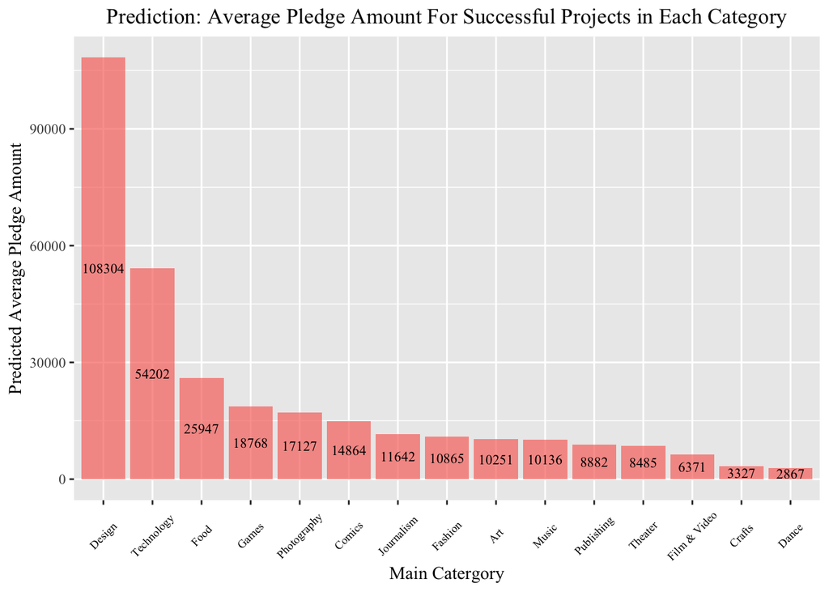

```r
df_test2 = test.data %>%
   filter(predict.state == 'successful')%>%
  group_by(main_category)%>%
  summarise(avg_pledge = mean(predicted.y))%>%
  arrange(desc(avg_pledge))

df_test2 %>%
  ggplot(aes(x=fct_rev(reorder(main_category,avg_pledge)),y=avg_pledge,fill='#EEB4B4'))+
  geom_bar(stat = 'identity',alpha = 0.7)+
  theme(legend.position="none") +
  ggtitle("Prediction: Average Pledge Amount For Successful Projects in Each Category") +
  xlab("Main Catergory") +
  ylab("Predicted Average Pledge Amount") +
  theme(axis.text.x = element_text(size = 7, color = "black", face = "plain", vjust = 0.5, hjust = 0.5, angle = 45),plot.title = element_text(hjust = 0.5),text=element_text(family="Times New Roman"))+
  geom_text(aes(label = round(avg_pledge,0)), position = position_stack(vjust = 0.5), family = "Times New Roman", size = 3)
```

According to our visualization, we showed the average pledge amount of successful projects in each category. Successful projects in Design and Technology have significantly large amounts of predicted average pledge amount.

**Calculating total predicted revenue for each category**

```r
df_test3 = test.data %>%
  filter(predict.state == 'successful')%>%
  group_by(main_category)%>%
  summarise(revenue = sum(round(predicted.y,0))*0.05) %>%
  arrange(desc(revenue,0))%>%
  kable()
df_test3
```

| main_category | revenue |
| --- | --- |
| Design | 525275.05 |
| Technology | 414649.25 |
| Games | 135131.65 |
| Fashion | 47263.95 |
| Music | 44598.55 |
| Art | 42542.25 |
| Publishing | 37304.35 |
| Food | 36325.90 |
| Film & Video | 30264.20 |
| Comics | 21553.10 |
| Photography | 11989.15 |
| Theater | 5939.25 |
| Journalism | 5239.00 |
| Crafts | 3825.80 |
| Dance | 1003.50 |

Based on our prediction, we predicted that categories with top 5 Predicted Revenue are Design, Technology, Games, Fashion and Music.

#### 8.Conclusion

**a. Variables lead to successful projects and higher pledge amount of projects:**

A reasonable goal, a large amount of backers and diversified strategy for different categories are important variables that lead to successful projects and higher pledge amount of projects.

**b. Recommendations for increasing Kickstarter’s revenue**

1. Kickstarter should guide projects to set reasonable and reachable goals.
2. Kickstarter should promote for projects to attract more backers:
- Advertise the Kickstarter website to increase the visitor volume.
3. Kickstarter should diversify promotion strategy based on categories and months:
- Kickstarter should promote for Technology heavily in April, September and November.
4. Kickstarter should invite more projects:
- Dance, Theater and Comics: High successful rates but small number of projects
- Technology: High average pledge amount & high average number of backers

**c. Prediction for current live projects**

We predicted that the categories with top 5 successful rate are Comics, Games, Photography, Art and Technology and categories with top 5 Predicted Revenue are Design, Technology, Games, Fashion and Music.

### Appendix:

**Appendix 1**

**d. the best model**

Our best model is the one with the lowest prediction error:

pledged= backers+ goal+ factor(main_category) x backers

```r
#See result in appendix 1
summary(lm_6)
```

```
##
## Call:
## lm(formula = pledged ~ backers + goal + factor(main_category) *
##     backers, data = training.data)
##
## Residuals:
##      Min       1Q   Median       3Q      Max
## -9635668    -1961     -987      228 12183872
##
## Coefficients:
##                                                 Estimate     Std. Error
## (Intercept)                                 259.82595940   400.42596624
## backers                                      68.78951771     1.77343829
## goal                                          0.00019794     0.00009888
## factor(main_category)Comics               -1568.09850777   779.37477914
## factor(main_category)Crafts                 287.80311362   820.75083294
## factor(main_category)Dance                 1081.05708294  1230.08480230
## factor(main_category)Design               -1117.39948907   564.64913480
## factor(main_category)Fashion               1272.84105703   604.39200406
## factor(main_category)Film & Video          1258.10902848   480.40040770
## factor(main_category)Food                  -785.42981423   588.43042151
## factor(main_category)Games                 2741.91262709   549.38671740
## factor(main_category)Journalism             122.02169065  1080.21783317
## factor(main_category)Music                  634.17622658   502.12285522
## factor(main_category)Photography           -791.87633038   776.03650093
## factor(main_category)Publishing             725.11074407   524.72031636
## factor(main_category)Technology            9061.00976337   555.81134652
## factor(main_category)Theater                -11.20079949   791.30631904
## backers:factor(main_category)Comics         -10.54814129     2.33070684
## backers:factor(main_category)Crafts         -26.69546456     4.27502105
## backers:factor(main_category)Dance          -18.07165377    11.46971347
## backers:factor(main_category)Design          35.14534588     1.78886223
## backers:factor(main_category)Fashion          1.66889245     2.12876223
## backers:factor(main_category)Film & Video     2.71472993     1.82736705
## backers:factor(main_category)Food            35.67192713     2.34823046
## backers:factor(main_category)Games          -11.78637807     1.78037623
## backers:factor(main_category)Journalism      -9.44667505     6.08573671
## backers:factor(main_category)Music          -12.58483387     2.22931613
## backers:factor(main_category)Photography     34.26365412     4.77440655
## backers:factor(main_category)Publishing     -25.19835892     2.06400468
```

[output cut: 25 more lines]

```
## backers:factor(main_category)Film & Video   1.486              0.13739
## backers:factor(main_category)Food          15.191 < 0.0000000000000002 ***
## backers:factor(main_category)Games         -6.620    0.000000000035941 ***
## backers:factor(main_category)Journalism    -1.552              0.12060
## backers:factor(main_category)Music         -5.645    0.000000016518216 ***
## backers:factor(main_category)Photography    7.177    0.000000000000717 ***
## backers:factor(main_category)Publishing   -12.208 < 0.0000000000000002 ***
## backers:factor(main_category)Technology     4.378    0.000011984317683 ***
## backers:factor(main_category)Theater        1.849              0.06450 .
## ---
## Signif. codes:  0 '***' 0.001 '**' 0.01 '*' 0.05 '.' 0.1 ' ' 1
##
## Residual standard error: 59440 on 298477 degrees of freedom
## Multiple R-squared:  0.5966, Adjusted R-squared:  0.5966
## F-statistic: 1.472e+04 on 30 and 298477 DF,  p-value: < 0.00000000000000022
```

**Appendix 2**

**add the segmentention_group variable into previous regression**

```r
#Create the segmentention_group variable
df<- df%>%mutate(segmentation_group=seg.k4$cluster)
#see result in Appendix 2
lm_segmentation = lm(pledged~factor(main_category)*backers + goal+factor(segmentation_group),data = df)
summary(lm_segmentation)
```

```
##
## Call:
## lm(formula = pledged ~ factor(main_category) * backers + goal +
##     factor(segmentation_group), data = df)
##
## Residuals:
##       Min        1Q    Median        3Q       Max
## -10340337     -3537      -124      1375  11535821
##
## Coefficients:
##                                                  Estimate      Std. Error
## (Intercept)                                589126.1132787   13515.7309897
## factor(main_category)Comics                 -1850.5672661     752.9612610
## factor(main_category)Crafts                  1215.4328329     794.8349638
## factor(main_category)Dance                    484.2388029    1196.7400190
## factor(main_category)Design                 -1132.0378802     545.2776894
## factor(main_category)Fashion                 2136.7821773     584.4459681
## factor(main_category)Film & Video            1855.7376746     463.1159340
## factor(main_category)Food                     340.1039851     569.2000810
## factor(main_category)Games                   3272.4329426     530.5508356
## factor(main_category)Journalism              1275.6489496    1046.6366088
## factor(main_category)Music                    472.5969944     484.3275281
## factor(main_category)Photography                9.5479530     750.5006810
## factor(main_category)Publishing              1264.9567903     506.3861751
## factor(main_category)Technology             10490.4848909     538.1090478
## factor(main_category)Theater                 -583.2141926     766.9752896
## backers                                        71.8028699       1.6958279
## goal                                            0.0012891       0.0002144
## factor(segmentation_group)2               -586415.7300346   13499.4677488
## factor(segmentation_group)3               -590987.0918732   13519.1807517
## factor(segmentation_group)4               -698239.7672236   23956.0309883
## factor(main_category)Comics:backers           -15.8993570       2.2586029
## factor(main_category)Crafts:backers           -32.2446493       4.2669033
## factor(main_category)Dance:backers            -27.4316669      11.4809054
## factor(main_category)Design:backers            32.8794531       1.7129778
## factor(main_category)Fashion:backers           -2.2050505       2.0652443
## factor(main_category)Film & Video:backers      -6.7725065       1.7565718
## factor(main_category)Food:backers              26.1464683       2.2639231
## factor(main_category)Games:backers            -16.7513339       1.7065420
## factor(main_category)Journalism:backers       -17.3267415       6.0476960
```

[output cut: 31 more lines]

```
## factor(main_category)Film & Video:backers  -3.856             0.000116 ***
## factor(main_category)Food:backers          11.549 < 0.0000000000000002 ***
## factor(main_category)Games:backers         -9.816 < 0.0000000000000002 ***
## factor(main_category)Journalism:backers    -2.865             0.004170 **
## factor(main_category)Music:backers         -8.335 < 0.0000000000000002 ***
## factor(main_category)Photography:backers    5.230   0.0000001699931635 ***
## factor(main_category)Publishing:backers   -14.329 < 0.0000000000000002 ***
## factor(main_category)Technology:backers     2.166             0.030317 *
## factor(main_category)Theater:backers        0.449             0.653076
## ---
## Signif. codes:  0 '***' 0.001 '**' 0.01 '*' 0.05 '.' 0.1 ' ' 1
##
## Residual standard error: 60480 on 331641 degrees of freedom
## Multiple R-squared:  0.6091, Adjusted R-squared:  0.6091
## F-statistic: 1.566e+04 on 33 and 331641 DF,  p-value: < 0.00000000000000022
```